# RNAseq 2

Ryota Chijimatsu

2023年6月

# 1. RNAseqデータのデータ分布

[参考]  
- https://bi.biopapyrus.jp/rnaseq/analysis/de-analysis/  
- https://bi.biopapyrus.jp/rnaseq/readcount-dispersion.html  
- https://speakerdeck.com/cakkby/nazeren-harna-seqfalseridokauntowofu-falseer-xiang-fen-bu-nicong-utokao-erufalseka

普段のwetな実験で群によって値が異なることを検定するとき、T検定やU検定をよく使用します。

RNAseqデータでも、各遺伝子の平均発現量が群によって異なるのかT検定(U検定)を遺伝子の数だけ繰り返しても良いのでしょうか。 検定を行うにはデータがどんな分布に従うのかを考える必要がありました。T検定なら各遺伝子の発現が正規分布に従う必要があります。

しかしながら、RNAseqでは各遺伝子の発現が正規分布に従っているとは考えられていません。technical replicateではポアソン分布、biological replicateでは負の二項分布に従うとされています。

## 1-1. technical replicateが従う分布

RNAseqデータから遺伝子Xのリードを取り出す場合、遺伝子Xか遺伝子X以外かの二項分布に当てはめることができます。しかし、全遺伝子中の遺伝子Xの発現比率を考えると、遺伝子Xのリードが得られる確率は非常に小さくなります。

この少ない確率の現象 (総リードを数える中で遺伝子Xリードが取り出されること)がA回起きる場合の確率はポアソン分布から求めることができます。

ポアソン分布の大きな特徴として、平均と分散が同じことが挙げられます。 つまり遺伝子Xの発現平均が10なら分散も10となります。

technical replicateがポアソン分布に従う様子を見てみます。

こちらの論文のデモデータを使用します。ヒト腎臓、ヒト肝臓をそれぞれN=5ずつのtechnical replicateでRNAseqを行った研究です。 https://pubmed.ncbi.nlm.nih.gov/18550803/

```r
dat <- read.delim(file = "technical_replicate.txt",
                  row.names = 1)
```

```r
head(dat)
```

|  | R1L1Kidney | R1L3Kidney | R1L7Kidney | R2L2Kidney | R2L6Kidney | R1L2Liver | R1L4Liver | R1L6Liver | R1L8Liver | R2L3Liver |
| --- | --- | --- | --- | --- | --- | --- | --- | --- | --- | --- |
| ENSG00000146556 | 0 | 0 | 0 | 0 | 0 | 0 | 0 | 0 | 0 | 0 |
| ENSG00000197194 | 0 | 0 | 0 | 0 | 0 | 0 | 0 | 0 | 0 | 0 |
| ENSG00000197490 | 0 | 0 | 0 | 0 | 0 | 0 | 0 | 0 | 0 | 0 |
| ENSG00000205292 | 0 | 0 | 0 | 0 | 0 | 0 | 0 | 0 | 0 | 0 |
| ENSG00000177693 | 0 | 0 | 0 | 0 | 0 | 0 | 0 | 0 | 0 | 0 |
| ENSG00000209338 | 0 | 0 | 0 | 0 | 0 | 0 | 0 | 0 | 0 | 0 |

```r
dim(dat)
```

```
## [1] 32000    10
```

総発現量を揃えておきます。

```r
dat <- apply(X = dat,MARGIN = 2, FUN = function(x){
  1e6 * x/sum(x)
})
```

腎臓のデータを取り出します。

```r
dat.1 <- dat[,1:5]
```

遺伝子ごとの平均と分散を求めます。

```r
dat.1_mean <- rowMeans(dat.1) # apply(dat.1, MARGIN = 1, FUN = mean)
dat.1_var <- apply(dat.1, MARGIN = 1, FUN = var)
```

平均と分散の関係を可視化します。赤線はy = xの線になります。

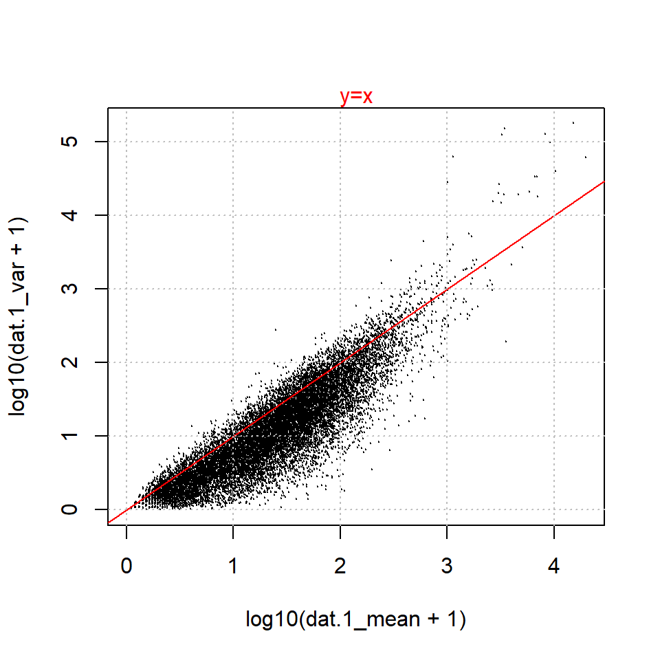

```r
plot(x = log10(dat.1_mean + 1), y = log10(dat.1_var + 1), cex = 0.1)
lm_res <- lm(log10(dat.1_var + 1)~log10(dat.1_mean + 1), na.action = "na.exclude")
abline(a = 0, b = 1, col = "red")
mtext(text = "y=x", col = "red")
grid(col="gray", lty="dotted")
```

平均と分散が似た値であることがわかります。

肝臓のtechnical replicateでも同様の結果が得られます。

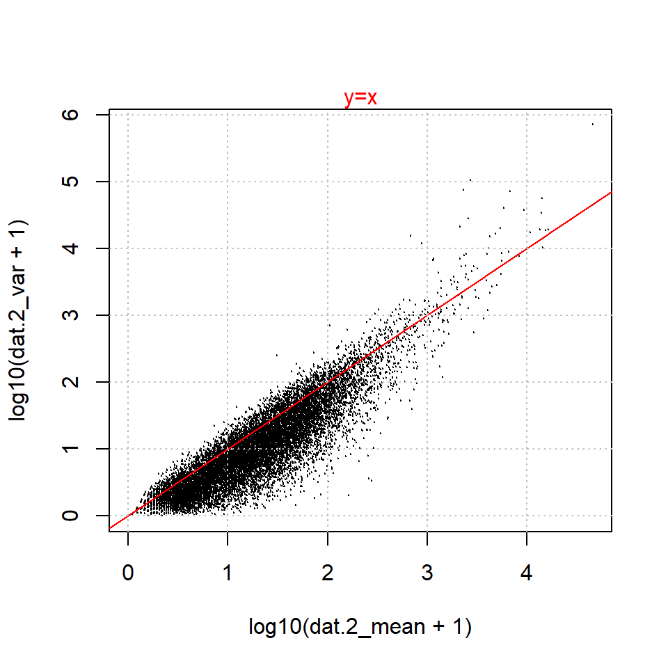

```r
dat.2 <- dat[,6:10]
dat.2_mean <- rowMeans(dat.2)
dat.2_var <- apply(dat.2, MARGIN = 1, FUN = var)

plot(x = log10(dat.2_mean + 1), y = log10(dat.2_var + 1), cex = 0.1)
lm_res <- lm(log10(dat.2_var + 1)~log10(dat.2_mean + 1))
abline(a = 0, b = 1, col = "red")
mtext(text = "y=x", col = "red")
grid(col="gray", lty="dotted")
```

この前提があれば、全サンプルの遺伝子Xの平均値を出せば、各サンプルの遺伝子Xの発現量が得られる確率がわかります。

lamda = mean = var = 10の時、遺伝子Xのリード数が1の確率、5の確率、10の確率。

```r
dpois(x = 1, lambda = 10)
```

```
## [1] 0.0004539993
```

```r
dpois(x = 5, lambda = 10)
```

```
## [1] 0.03783327
```

```r
dpois(x = 10, lambda = 10)
```

```
## [1] 0.12511
```

## 1-2. biological replicateが従う分布

こちらのデモデータを使用します。https://www.iu.a.u-tokyo.ac.jp/~kadota/r_seq.html#count_simulation_RNAseq_biological_kiso

N=3 vs N=3の6サンプルのデータで、各群のreplicateはbiological replicateです。

```r
dat2 <- read.delim(file = "biological_replicate.txt",
                   row.names = 1)

head(dat2)
```

|  | G1_rep1 | G1_rep2 | G1_rep3 | G2_rep1 | G2_rep2 | G2_rep3 |
| --- | --- | --- | --- | --- | --- | --- |
| gene_1 | 36 | 56 | 144 | 2 | 1 | 0 |
| gene_2 | 84 | 152 | 124 | 52 | 37 | 28 |
| gene_3 | 592 | 840 | 800 | 151 | 257 | 200 |
| gene_4 | 0 | 8 | 4 | 1 | 1 | 3 |
| gene_5 | 32 | 32 | 0 | 1 | 1 | 0 |
| gene_6 | 4 | 0 | 24 | 4 | 10 | 0 |

```r
dim(dat2)
```

```
## [1] 10000     6
```

合計値を揃えておきます。

```r
dat2 <- apply(X = dat2,MARGIN = 2, FUN = function(x){
  1e6 * x/sum(x)
})
```

それぞれの群のデータを抜き出して、群の中の各遺伝子の平均と分散を見てみます。

```r
dat.2.1 <- dat2[,1:3]
dat.2.2 <- dat2[,4:6]
```

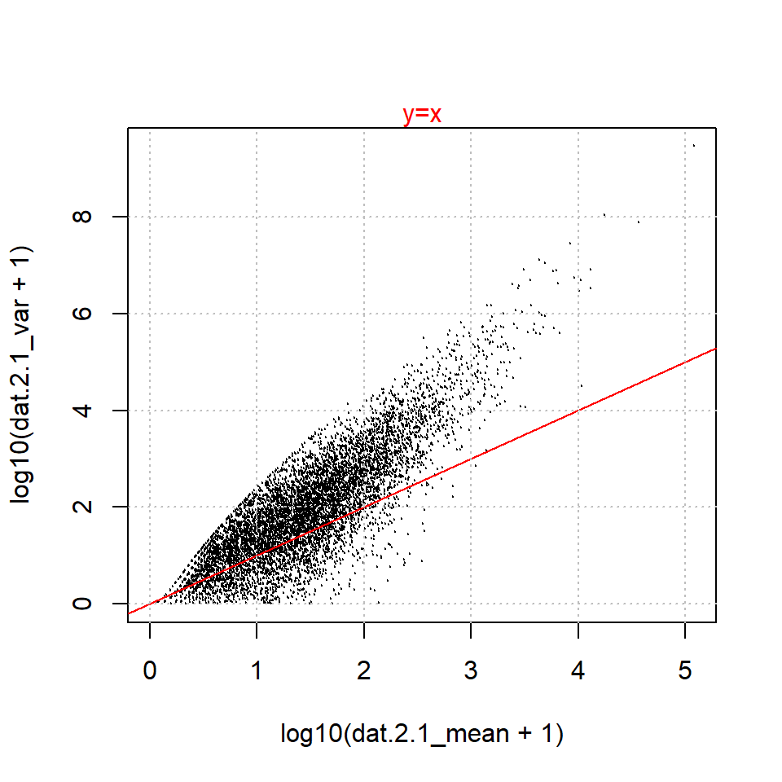

```r
dat.2.1_mean <- rowMeans(dat.2.1)
dat.2.1_var <- apply(dat.2.1, MARGIN = 1, FUN = var)

plot(x = log10(dat.2.1_mean + 1), y = log10(dat.2.1_var + 1), cex = 0.1)
lm_res <- lm(log10(dat.2.1_var + 1)~log10(dat.2.1_mean + 1))
abline(a = 0, b = 1, col = "red")
mtext(text = "y=x", col = "red")
grid(col="gray", lty="dotted")
```

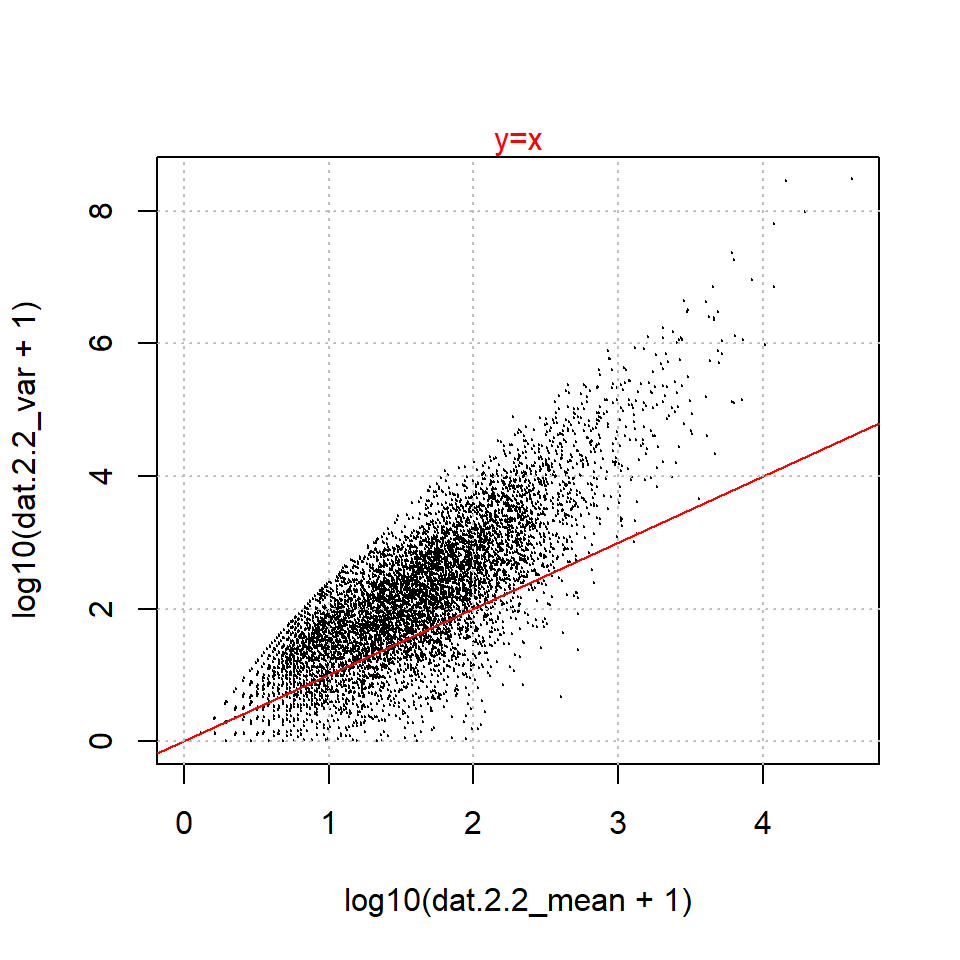

```r
dat.2.2_mean <- rowMeans(dat.2.2)
dat.2.2_var <- apply(dat.2.2, MARGIN = 1, FUN = var)

plot(x = log10(dat.2.2_mean + 1), y = log10(dat.2.2_var + 1), cex = 0.1)
lm_res <- lm(log10(dat.2.2_var + 1)~log10(dat.2.2_mean + 1))
abline(a = 0, b = 1, col = "red")
mtext(text = "y=x", col = "red")
grid(col="gray", lty="dotted")
```

biological replicateでは 平均 = 分散 にはなりません。 (全体的なトレンドはあります。分散の値は高発現領域でより高く出ています。ただ分散が取り得る範囲が大きいのは低発現領域になります。)

各遺伝子の発現はポアソン分布に従っているとは言えないため、ポアソン分布を使った検定は不適切となります。ポアソン分布に当てはめると、高発現領域によりDEGが多く検出されてしまいます。

technical replicateでは総リードから遺伝子Xのリードが取り出される確率はどのサンプルでも同じであることが想定されますが、biological replicateではその確率がサンプルごとに変わります。  
その結果、遺伝子ごとに分散が大きくなり、分散 > 平均 のような状況が生じます。

これに対応しているのが負の二項分布です。 **edgeR**や**DESeq2**は負の二項分布を考慮した発現変動解析ツールです。遺伝子ごとの分散を推定した後、負の二項分布に当てはめてその確率を検定します。

edgeRでは 遺伝子の分散と平均の関係を次のようにモデル化しています。φは定数ではなく、遺伝子ごとに異なります。  
このφを経験ベイズ法などを用いて推定します。

$$分散 = 平均 + φ*平均^2$$

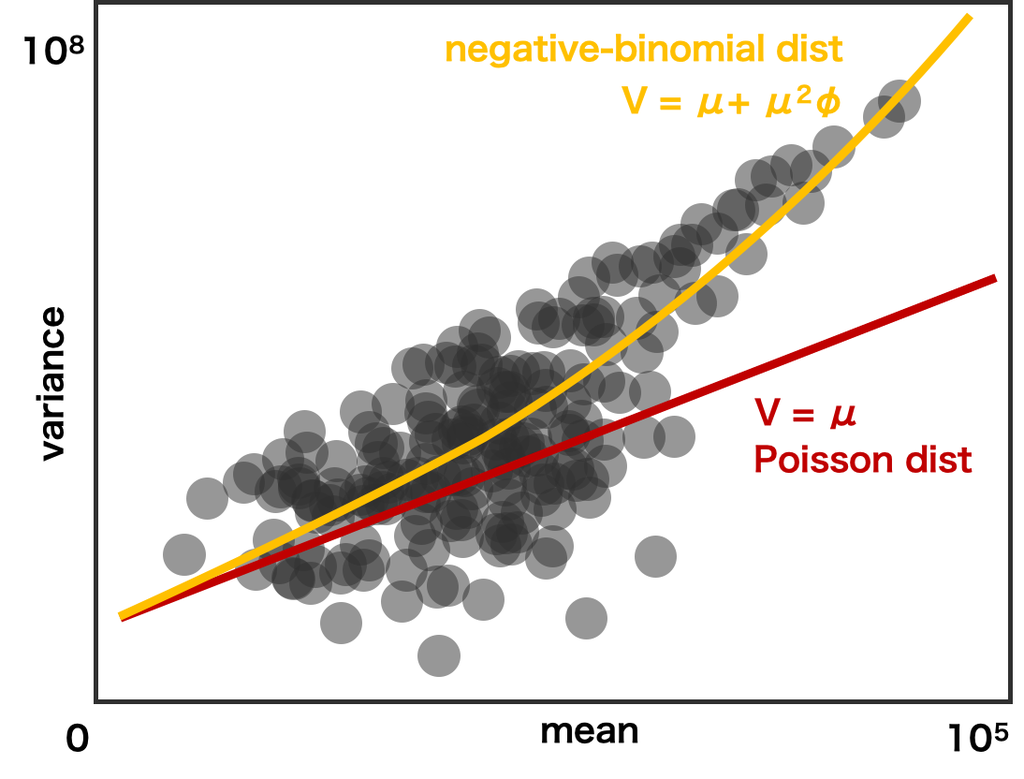

https://bi.biopapyrus.jp/rnaseq/analysis/de-analysis/

# 2. edgeRでの発現変動解析

RNAseqの発現変動遺伝子の検定にはedgeRとDESeq2がよく使用されます。

edgeRは公式チュートリアルも充実しています。 https://bioconductor.org/packages/release/bioc/html/edgeR.html

計算原理はポアソン分布、負の二項分布、経験的ベイズ、疑似尤度比検定、一般化線形モデル、、などの知識が無いと理解できません。 ただ理解してなくとも使用はできます。

日本語解説ページ

- https://heavywatal.github.io/rstats/edger.html
- https://shiokoji11235.com/rna-seq-analysis-part2

```r
# install.packages("BiocManager")
# BiocManager::install("edgeR")
library(edgeR)
library(dplyr)
```

```r
library(ggplot2)
library(pheatmap)
```

## 2-1 デモデータ

edgeRチュートリアル Case studiesのデータを使用します。

口腔がん 3例、正常組織 3例のRNAseq  
https://journals.plos.org/plosone/article?id=10.1371/journal.pone.0009317

Supplement table.1から不要なデータを除いたものを事前に用意しておきます。 必要な情報は、遺伝子に関する情報（IDかSYMBOL）とサンプルに関する情報（サンプル名）、そして発現値になります。

```r
x <- read.csv("RNAseq_Case1.csv")
dim(x)
```

```
## [1] 15668     8
```

```r
head(x)
```

|  | idRefSeq | nameOfGene | X8N | X8T | X33N | X33T | X51N | X51T |
| --- | --- | --- | --- | --- | --- | --- | --- | --- |
| 1 | NM_182502 | TMPRSS11B | 2592 | 3 | 7805 | 321 | 3372 | 9 |
| 2 | NM_003280 | TNNC1 | 1684 | 0 | 1787 | 7 | 4894 | 559 |
| 3 | NM_152381 | XIRP2 | 9915 | 15 | 10396 | 48 | 23309 | 7181 |
| 4 | NM_022438 | MAL | 2496 | 2 | 3585 | 239 | 1596 | 7 |
| 5 | NM_001100112 | MYH2 | 4389 | 7 | 7944 | 16 | 9262 | 1818 |
| 6 | NM_017534 | MYH2 | 4402 | 7 | 7943 | 16 | 9244 | 1815 |

Rではファイル読み込み時に列名や行名を自動で変換することがあります。 例えばハイフンや半角スペースなどがピリオドに変換されたりします。 この例では数字から始まる列名の前にXがついていました。

もし自動変換を防ぎたければcheck.names引数をFALSEにします。

```r
x <- read.csv("RNAseq_Case1.csv", check.names = F)
head(x)
```

|  | idRefSeq | nameOfGene | 8N | 8T | 33N | 33T | 51N | 51T |
| --- | --- | --- | --- | --- | --- | --- | --- | --- |
| 1 | NM_182502 | TMPRSS11B | 2592 | 3 | 7805 | 321 | 3372 | 9 |
| 2 | NM_003280 | TNNC1 | 1684 | 0 | 1787 | 7 | 4894 | 559 |
| 3 | NM_152381 | XIRP2 | 9915 | 15 | 10396 | 48 | 23309 | 7181 |
| 4 | NM_022438 | MAL | 2496 | 2 | 3585 | 239 | 1596 | 7 |
| 5 | NM_001100112 | MYH2 | 4389 | 7 | 7944 | 16 | 9262 | 1818 |
| 6 | NM_017534 | MYH2 | 4402 | 7 | 7943 | 16 | 9244 | 1815 |

Excel等で操作したファイルを読み込んだ際はstr関数で列の型を確認する習慣をつけておきましょう。  
数字だと思っても、文字列となっていることがあります。

```r
str(x)
```

```
## 'data.frame':    15668 obs. of  8 variables:
##  $ idRefSeq  : chr  "NM_182502" "NM_003280" "NM_152381" "NM_022438" ...
##  $ nameOfGene: chr  "TMPRSS11B" "TNNC1" "XIRP2" "MAL" ...
##  $ 8N        : int  2592 1684 9915 2496 4389 4402 2697 519 4160 2073 ...
##  $ 8T        : int  3 0 15 2 7 7 3 0 7 1 ...
##  $ 33N       : int  7805 1787 10396 3585 7944 7943 3941 857 3425 2937 ...
##  $ 33T       : int  321 7 48 239 16 16 265 3 516 96 ...
##  $ 51N       : int  3372 4894 23309 1596 9262 9244 1750 833 1720 1351 ...
##  $ 51T       : int  9 559 7181 7 1818 1815 8 83 5 7 ...
```

## 2-2 edgeR用オブジェクトのDGEListを作成

edgeRではDGElistというパッケージ専用のクラスのオブジェクトで解析を進めます。 DGEListには発現マトリクス、遺伝子情報、群情報をそれぞれ指定します。

```r
# 発現マトリクス
counts <- x[,3:8]
# 遺伝子情報
genes <- x[,1:2]
# 群情報 (発現マトリクスのサンプル順に合わせる)
group <-c("Normal","Tumor","Normal","Tumor","Normal","Tumor")

y <- DGEList(counts= counts,
             genes= genes,
             group = group)
class(y)
```

```
## [1] "DGEList"
## attr(,"package")
## [1] "edgeR"
```

このようにパッケージごとに用意されたクラスを扱うことはよくあります。大事なのはそれらのデータ構造を把握して、欲しい情報がどこに保存されているのかを知ることです。

str関数で構造を見てみると、基本はリスト型と類似したデータ構造なのがわかります。

```r
str(y)
```

```
## Formal class 'DGEList' [package "edgeR"] with 1 slot
##   ..@ .Data:List of 3
##   .. ..$ : int [1:15668, 1:6] 2592 1684 9915 2496 4389 4402 2697 519 4160 2073 ...
##   .. .. ..- attr(*, "dimnames")=List of 2
##   .. .. .. ..$ : chr [1:15668] "1" "2" "3" "4" ...
##   .. .. .. ..$ : chr [1:6] "8N" "8T" "33N" "33T" ...
##   .. ..$ :'data.frame':  6 obs. of  3 variables:
##   .. .. ..$ group       : Factor w/ 2 levels "Normal","Tumor": 1 2 1 2 1 2
##   .. .. ..$ lib.size    : num [1:6] 12090121 10123913 19890767 18590376 33878462 ...
##   .. .. ..$ norm.factors: num [1:6] 1 1 1 1 1 1
##   .. ..$ :'data.frame':  15668 obs. of  2 variables:
##   .. .. ..$ idRefSeq  : chr [1:15668] "NM_182502" "NM_003280" "NM_152381" "NM_022438" ...
##   .. .. ..$ nameOfGene: chr [1:15668] "TMPRSS11B" "TNNC1" "XIRP2" "MAL" ...
##   ..$ names: chr [1:3] "counts" "samples" "genes"
```

### 群のlevel設定

発現変動解析では対照群に対して何倍変化したかという値を扱います。  
今回はNormalとTumorの2群ありますが、どちらが対照群なのかを明示していません。

strの出力を見ると、group情報は文字列からFactor型のデータに変換されていることが分かります。  
Factor型はレベルという概念があります。このレベルが先にある方が対照群となります。

```r
y$samples$group
```

```
## [1] Normal Tumor  Normal Tumor  Normal Tumor
## Levels: Normal Tumor
```

文字列ベクトルをFactor型ベクトルに変換するとき、アルファベット順でレベルが決まります。今回はたまたまNormalがアルファベット順で先だったので、都合よくNormalに対してTumorで何倍発現が変化しているかという解析ができます。

対照群を設定するためには、levels引数を自身で設定したfactor型ベクトルを渡す必要があります。

```r
# 群情報のFactor型ベクトル。level順はNormal, Tumor
group <- factor(c("Normal","Tumor","Normal","Tumor","Normal","Tumor"), levels = c("Normal", "Tumor"))

y <- DGEList(counts= counts,
             genes= genes,
             group = group)
```

もしくはNormalを1, Tumorを2として群情報を作っても良いです。  
group <- c(1,2,1,2,1,2)

## 2-3 重複遺伝子の除外

このデータにも遺伝子名が重複しているようです。(遺伝子IDは重複していない)

```r
length(unique(y$genes$idRefSeq))
```

```
## [1] 15668
```

```r
length(unique(y$genes$nameOfGene))
```

```
## [1] 10542
```

遺伝子の平均発現順に並び替えて、重複を除きます。

```r
# 遺伝子の平均発現を求め、その降順の場合の遺伝子順を取り出す
o <- order(rowSums(y$counts), decreasing=TRUE)
# DGEListのデータの遺伝子順を指定して上書き
y <- y[o,]
# 重複している遺伝子の箇所をTRUE
d <- duplicated(y$genes$nameOfGene)
# 重複していない遺伝子のみにする
y <- y[!d,]
dim(y)
```

```
## [1] 10542     6
```

## 2-4 遺伝子のフィルタリング

発現変動解析では低発現遺伝子や、各サンプルに非共通の遺伝子を解析対象から除外します。  
edgeRでは`filterByExpr`機能で低発現遺伝子の除去を行ってくれます。

```r
keep <- filterByExpr(y = y)

str(keep)
```

```
##  Named logi [1:10542] TRUE TRUE TRUE TRUE TRUE TRUE ...
##  - attr(*, "names")= chr [1:10542] "9497" "41" "3226" "4181" ...
```

```r
table(keep)
```

```
## keep
##  TRUE
## 10542
```

`filterByExpr`の出力はTRUE/FALSEの論理値ベクトルです。

DGEListオブジェクトのindexに論理値ベクトルを入れて、TRUEの遺伝子だけを残します。(この例では全遺伝子が残っているので変化ありません)

```r
y <- y[keep, ]
dim(y)
```

```
## [1] 10542     6
```

自身で閾値を設定してフィルタリングしても構いません。

## 2-5 ライブラリーサイズ

lib.size（ライブラリーサイズ）は総カウント値のことです。総カウント値は取得したデータ量に依存します。

```r
y[["samples"]][["lib.size"]]
```

```
## [1] 12090121 10123913 19890767 18590376 33878462 21832978
```

発現値をCPMに変換して、さらに対数変換して、ライブラリーサイズの違いを見てみます。

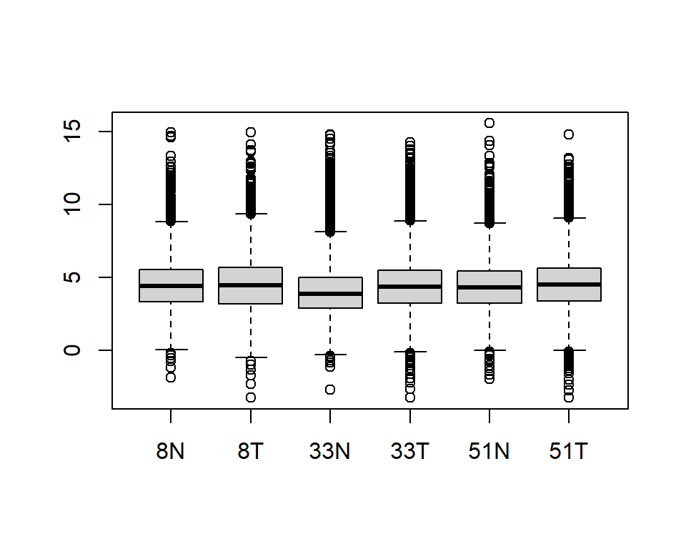

```r
tmp <- cpm(y = y, log = TRUE)
boxplot(tmp)
```

## 2-6 TMM正規化

edgeRではTMM正規化という手法で、ライブラリーサイズの差を補正します。  
https://bi.biopapyrus.jp/rnaseq/analysis/normalizaiton/tmm.html

calcNormFactors関数を使うだけです。

```r
y <- calcNormFactors(y)

# 補正係数を確認
y[["samples"]][["norm.factors"]]
```

```
## [1] 1.0669450 1.1139395 0.7500512 1.0373671 0.9250611 1.1689679
```

calcNormFactorsを行うとライブラリーサイズが揃うことが確認できます。

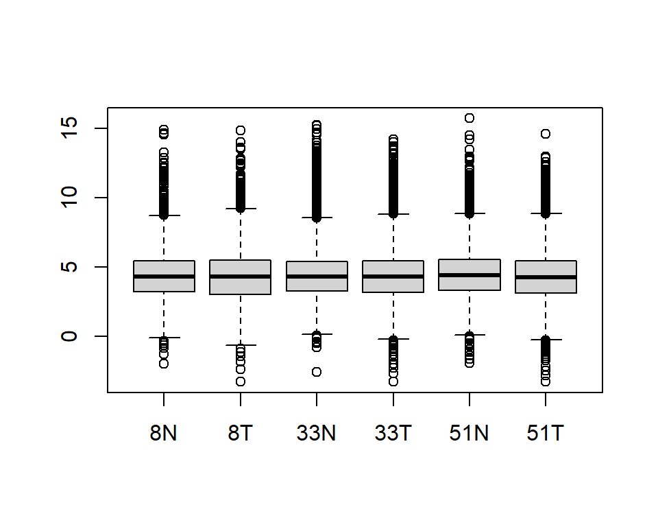

```r
tmp <- cpm(y = y, log = TRUE)
boxplot(tmp)
```

## 2-7 サンプルのクラスタリング

網羅的解析では自身が想定した群とは異なる偏りを持つことがあります。 例えば、NGSデータの取得を別日に行ったことや使用した試薬が変わったなどでも偏りが生じることがあります。

plotMDS機能を使うと、多次元尺度法という次元削減手法でサンプル間の違いを低次元で可視化してくれます。

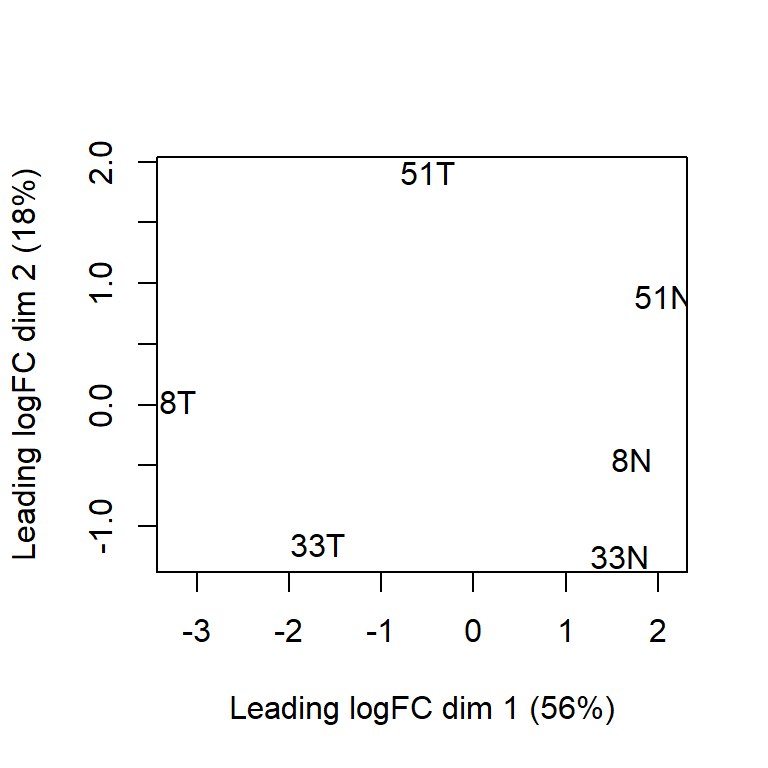

```r
plotMDS(y)
```

–> 正常群は近い位置関係にあるのに対し、腫瘍サンプルは郡内でもばらつきがあることが想定されます。

## 2-8 分散推定

RNAseqのデータは、低発現領域と高発現領域で分散が異なります。高発現領域程高い分散を持ちます。そのため全遺伝子を同じ分散と仮定して検定を行うと、高発現領域に発現変動遺伝子が多く見積もられてしまいます。

そのため遺伝子ごとに分散を推定します。`estimateDisp`機能を使うだけです。

```r
y <- estimateDisp(y)
```

```
## Using classic mode.
```

`plotBCV`機能で推定された分散を確認することができます。

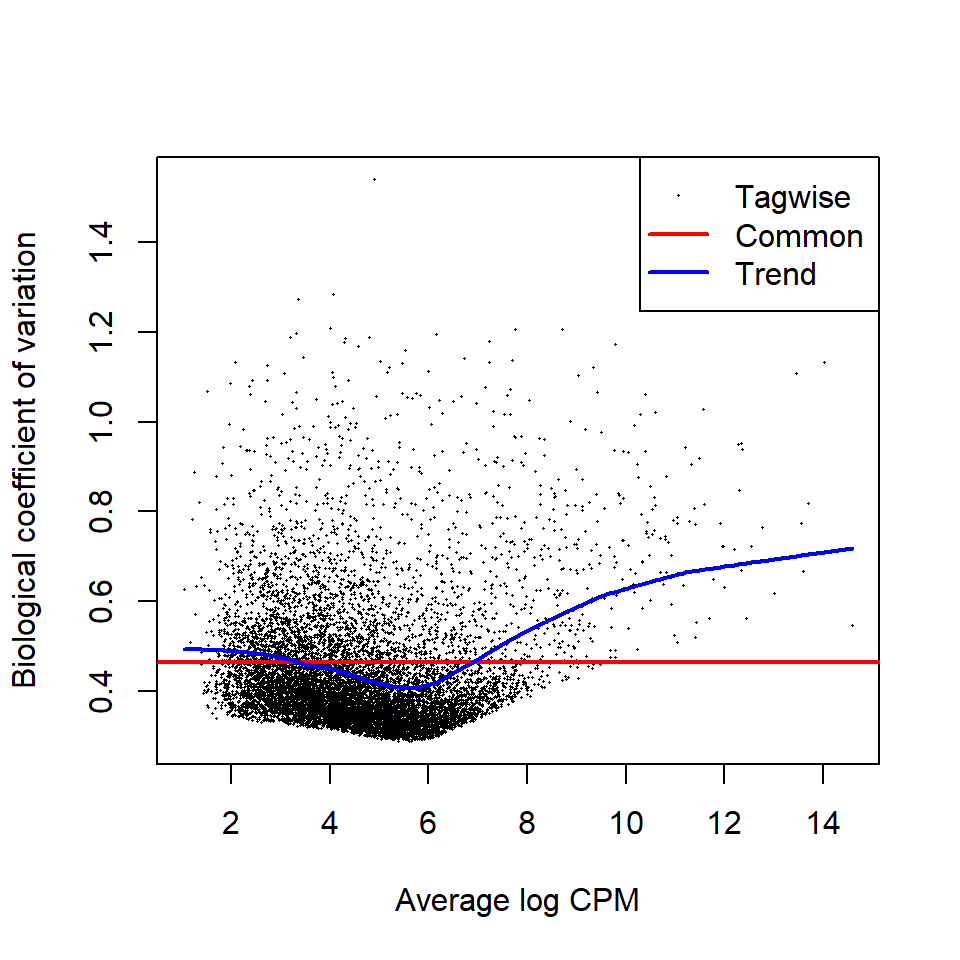

```r
plotBCV(y)
```

Commonは全遺伝子での分散、Tagwiseは各遺伝子ごとの分散です。このように遺伝子ごとに大きくことなる分散と全遺伝子を使った分散には乖離があることが分かります。

ここの解釈は以下のページがわかりやすいです。難解ですが。。 - https://bi.biopapyrus.jp/rnaseq/analysis/de-analysis/  
- https://speakerdeck.com/cakkby/nazeren-harna-seqfalseridokauntowofu-falseer-xiang-fen-bu-nicong-utokao-erufalseka?slide=13

## 2-9 発現変動検定

2群の発現差の有意差検定を行います。`exactTest`機能を使うだけです。

```r
dge <- exactTest(y)

str(dge)
```

```
## Formal class 'DGEExact' [package "edgeR"] with 1 slot
##   ..@ .Data:List of 3
##   .. ..$ :'data.frame':  10542 obs. of  3 variables:
##   .. .. ..$ logFC : num [1:10542] -0.156 -3.576 -0.765 -1.036 -0.382 ...
##   .. .. ..$ logCPM: num [1:10542] 14.6 14 13.7 13.6 13.6 ...
##   .. .. ..$ PValue: num [1:10542] 0.8103 0.0208 0.4423 0.2727 0.6338 ...
##   .. ..$ : chr [1:2] "Normal" "Tumor"
##   .. ..$ :'data.frame':  10542 obs. of  2 variables:
##   .. .. ..$ idRefSeq  : chr [1:10542] "NR_002819" "NM_133378" "NR_004380" "NR_002563" ...
##   .. .. ..$ nameOfGene: chr [1:10542] "MALAT1" "TTN" "SNORD104" "SNORD27" ...
##   ..$ names: chr [1:3] "table" "comparison" "genes"
```

MA plotで可視化してみます。`plotMD`機能で簡単に確認できます。縦軸は群の発現変動差、横軸は平均発現量です。

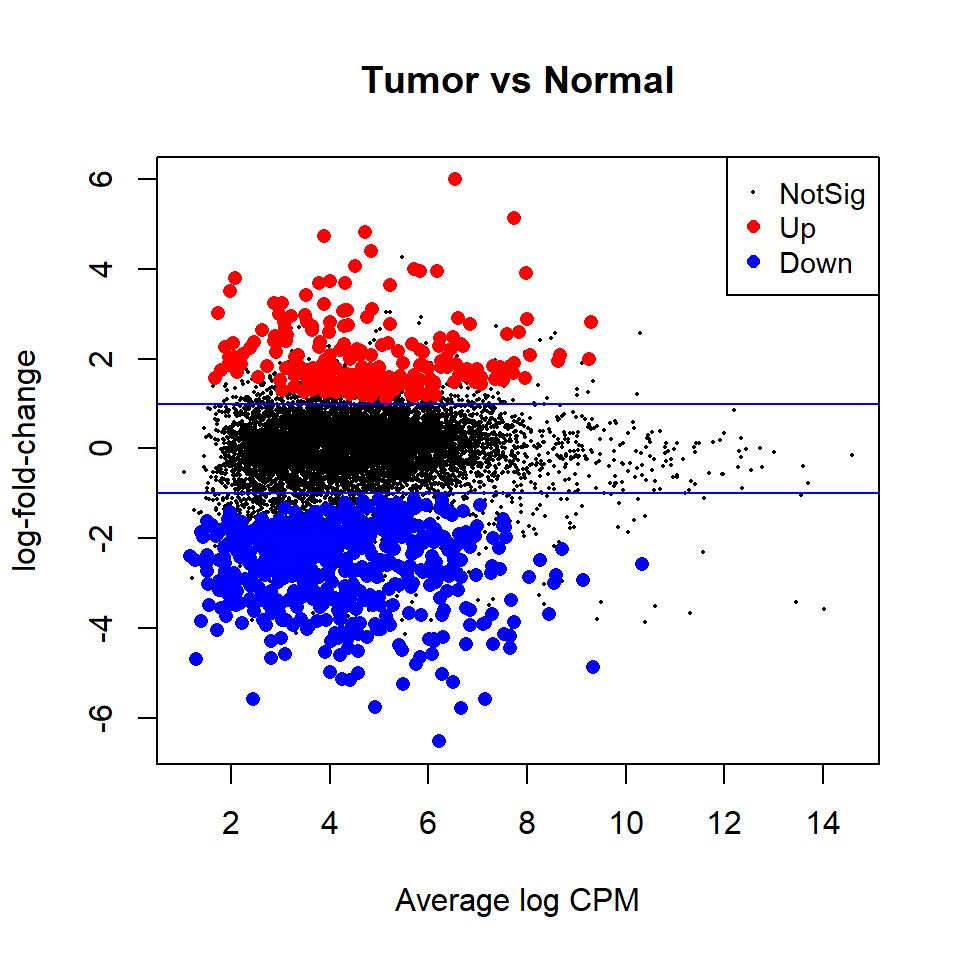

```r
plotMD(dge)

abline(h=c(-1, 1), col="blue") # cutoffの線を追記する。
```

上記の赤色、青色のDEGがそれぞれ幾つあるかは以下のように確認できます。

```r
de <- decideTestsDGE(dge,
                     adjust.method="BH", # p値の調整法
                     p.value=0.01, # 閾値となるp値
                     lfc=1 # 閾値となる発現変動差 log fold change
                     )
summary(de)
```

```
##        Tumor-Normal
## Down            292
## NotSig        10157
## Up               93
```

edgeRではdesign matrixを使った一般化線形モデルによる検定も行えます。これを使えば群以外のcovariant (患者の違いなど)や多群比較も行えます。

## 2-10 結果の書き出し

`topTags`機能では、有意な発現変動遺伝子の上位を確認する際に使用します。デフォルトではp値が低い順に上位10個を表示します。

```r
topTags(dge)
```

```
## Comparison of groups:  Tumor-Normal
##           idRefSeq nameOfGene     logFC   logCPM       PValue          FDR
## 102      NM_004320     ATP2A1 -4.480940 5.469060 8.935100e-16 7.483949e-12
## 200      NM_031469   SH3BGRL2 -4.032080 5.040447 1.419835e-15 7.483949e-12
## 53       NM_005609       PYGM -5.250392 5.491972 2.260963e-15 7.945023e-12
## 15663    NM_002820      PTHLH  4.001370 5.711116 5.324984e-15 1.403399e-11
## 270      NM_015278      SASH1 -3.325319 6.230338 1.112636e-13 2.345883e-10
## 95    NM_001039585      PTGFR -5.128840 4.244825 3.451721e-13 6.064673e-10
## 384      NM_003243     TGFBR3 -3.276803 4.787081 7.026371e-12 1.058172e-08
## 15642    NM_002899       RBP1  3.730675 4.008128 2.081435e-11 2.348797e-08
## 252      NM_005276       GPD1 -3.813476 2.638000 2.105532e-11 2.348797e-08
## 140      NM_007168      ABCA8 -3.905388 4.441189 2.228038e-11 2.348797e-08
```

`topTags`で全遺伝子を出力するようにして、data.frameの出力を得ます。

```r
DGE_result <- topTags(object = dge,
                      n = Inf)

str(DGE_result)
```

```
## Formal class 'TopTags' [package "edgeR"] with 1 slot
##   ..@ .Data:List of 4
##   .. ..$ :'data.frame':  10542 obs. of  6 variables:
##   .. .. ..$ idRefSeq  : chr [1:10542] "NM_004320" "NM_031469" "NM_005609" "NM_002820" ...
##   .. .. ..$ nameOfGene: chr [1:10542] "ATP2A1" "SH3BGRL2" "PYGM" "PTHLH" ...
##   .. .. ..$ logFC     : num [1:10542] -4.48 -4.03 -5.25 4 -3.33 ...
##   .. .. ..$ logCPM    : num [1:10542] 5.47 5.04 5.49 5.71 6.23 ...
##   .. .. ..$ PValue    : num [1:10542] 8.94e-16 1.42e-15 2.26e-15 5.32e-15 1.11e-13 ...
##   .. .. ..$ FDR       : num [1:10542] 7.48e-12 7.48e-12 7.95e-12 1.40e-11 2.35e-10 ...
##   .. ..$ : chr "BH"
##   .. ..$ : chr [1:2] "Normal" "Tumor"
##   .. ..$ : chr "exact"
##   ..$ names: chr [1:4] "table" "adjust.method" "comparison" "test"
```

`topTags`の出力のうち`table`の項目にdata.frameが保存されているのでこちらを取り出します。

```r
DGE_result <- DGE_result$table
```

```r
write.csv(x = DGE_result, "edgeR_DGE.csv", row.names = F)
```

## 2-11 DEGの代表的なplot

まずは可視化する遺伝子を選んでおきます。

```r
rownames(DGE_result) <- DGE_result$nameOfGene

up <- rownames(DGE_result[ DGE_result$logFC >= 1 &
                       DGE_result$FDR < 0.05, ])
length(up)
```

```
## [1] 220
```

```r
down <- rownames(DGE_result[ DGE_result$logFC <= -1 &
                       DGE_result$FDR < 0.05, ])
length(down)
```

```
## [1] 577
```

以下のようにすれば発現上昇遺伝子だけ、発現減少遺伝子だけを取り出すこともできます。

### Volcano plot

ggplotではdata.frameの列の情報に従って色や形状などを変更します。DEGの箇所に色を付けたplotを行うなら、DEGの箇所を示す列を作らなければなりません。

```r
# 新規列を作成
DGE_result$updown <- "not.sig"

# up遺伝子の行のupdown列にupと記載
DGE_result[ DGE_result$nameOfGene %in% up , "updown"] <- "up"
# down遺伝子の行のupdown列にdownと記載
DGE_result[ DGE_result$nameOfGene %in% down, "updown"] <- "down"

table(DGE_result$updown)
```

```
##
##    down not.sig      up
##     577    9745     220
```

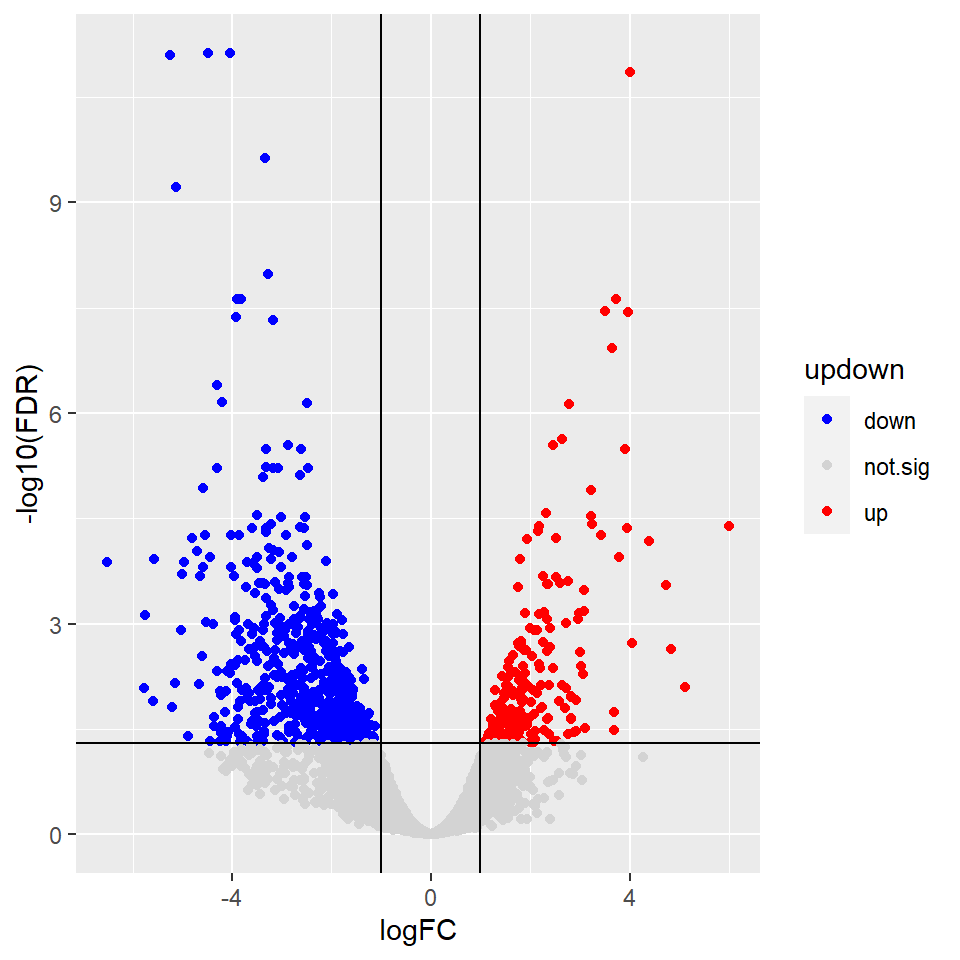

```r
ggplot(data = DGE_result, mapping = aes(x = logFC, y = -log10(FDR))) +
  # 散布図　updown列に従って色を付ける
  geom_point(aes(color = updown)) +
  # 色を自身で指定
  scale_color_manual(values = c("blue", "lightgray", "red")) +
  # 平行線を入れる
  geom_hline(yintercept = -log10(0.05)) +
  # 垂直線を入れる
  geom_vline(xintercept = -1) +
  # 垂直線を入れる
  geom_vline(xintercept = 1)
```

さらに有意差がより小さいものにラベルも追記してみます。

```r
high.sig <- rownames(DGE_result[ -log10(DGE_result$FDR) > 6, ])

# 新規列を作成
DGE_result$label <- ""

# high.sig遺伝子の箇所にhigh.sig遺伝子を入れる
DGE_result[ DGE_result$nameOfGene %in% high.sig , "label"] <- high.sig
```

```r
library(ggrepel)
```

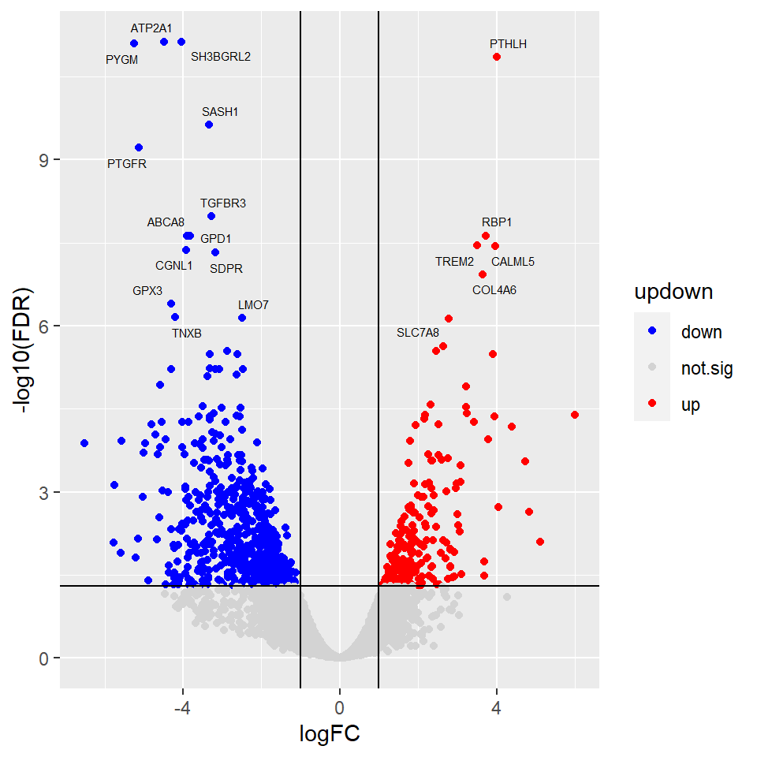

```r
ggplot(data = DGE_result, mapping = aes(x = logFC, y = -log10(FDR))) +
  # 散布図　updown列に従って色を付ける
  geom_point(aes(color = updown)) +
  # 色を自身で指定
  scale_color_manual(values = c("blue", "lightgray", "red")) +
  # 平行線を入れる
  geom_hline(yintercept = -log10(0.05)) +
  # 垂直線を入れる
  geom_vline(xintercept = -1) +
  # 垂直線を入れる
  geom_vline(xintercept = 1) +
  # high.sig遺伝子を表示
  geom_text_repel(aes(label = label), size = 2)
```

### MA plot

縦軸に群間発現差、横軸に平均発現量を取るplotです。

```r
# 発現変動の閾値以上か以下かを記録するための新規列を作成
DGE_result$updown <- "not_altered"
# up遺伝子の行のupdown列にupと記載
DGE_result[ DGE_result$logFC >= 1, "updown"] <- "up"
# down遺伝子の行のupdown列にdownと記載
DGE_result[ DGE_result$logFC <= -1, "updown"] <- "down"

# p値が閾値以上か以下か記録
DGE_result$p_cutoff <- "not.sig"
# 有意なDEG行のp_cutoff列にsigと記載
DGE_result[ DGE_result$nameOfGene %in% up | DGE_result$nameOfGene %in% down, "p_cutoff"] <- "sig"
```

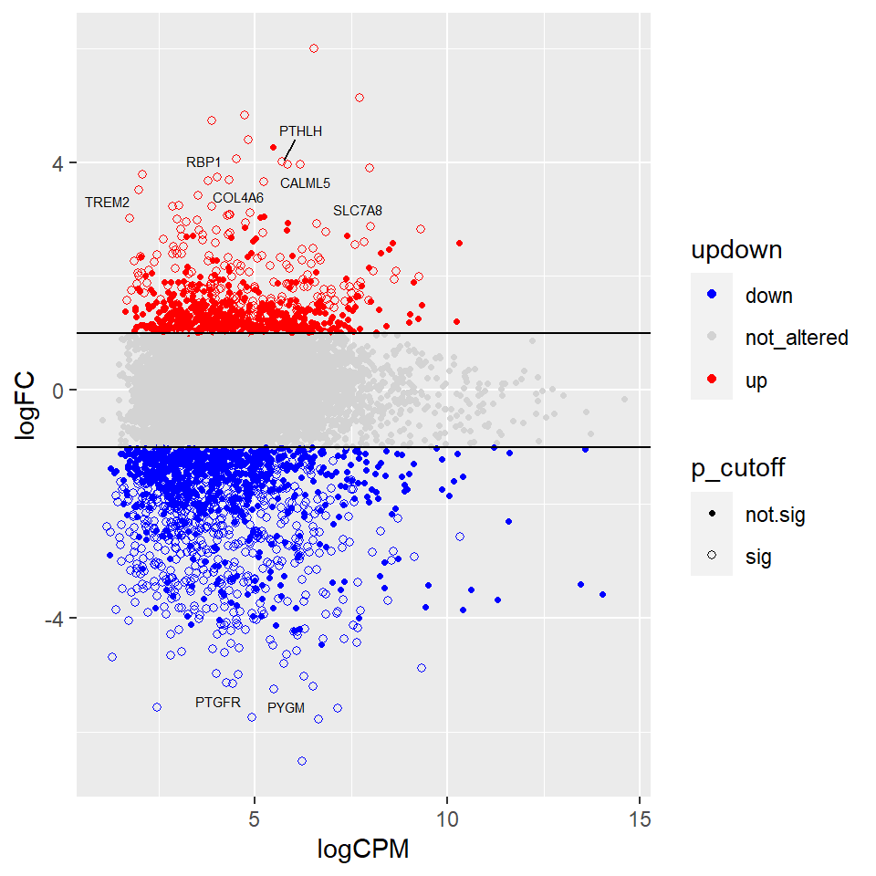

```r
ggplot(data = DGE_result, mapping = aes(x = logCPM, y = logFC)) +
  # 散布図　updown列に従って色を付けて、p値の閾値で点の形を変える。
  geom_point(aes(color = updown,
                 shape = p_cutoff)) +
  # 色を自身で指定
  scale_color_manual(values = c("blue", "lightgray", "red")) +
  # 点の形を指定
  scale_shape_manual(values = c(20, 1)) +
  # 平行線を入れる
  geom_hline(yintercept = 1) +
  geom_hline(yintercept = -1) +
  # high.sig遺伝子を表示
  geom_text_repel(aes(label = label), size = 2)
```

### Heatmap

元の発現マトリクスでDEGの発現量を可視化します。 その前に、edgeRの`cpm`機能でcount per millionの値を取得しておきます。

```r
mat <- cpm(y = y, log = TRUE)
rownames(mat) <- y$genes$nameOfGene
head(mat)
```

```
##                8N        8T      33N       33T      51N       51T
## MALAT1   14.53537 14.837204 14.95373 13.972121 14.47231 14.600163
## TTN      14.63631  6.739660 13.75749  7.365404 15.70663 12.874266
## SNORD104 12.23305 12.665868 15.25000 14.209833 12.68235 12.028752
## SNORD27  12.09353 12.293025 15.18077 13.720278 12.83733 12.370515
## SNORD26  12.85263 13.972050 14.69169 13.406340 12.95641 12.330379
## KRT13    14.89787  7.667135 14.55732 12.425124 12.72326  6.168409
```

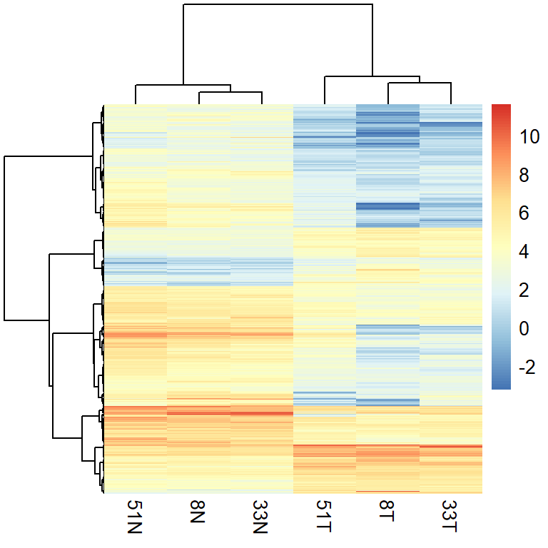

```r
# DEGのみの発現マトリクスを抽出
mat_DEG <- mat[c(up,down),]

# pheatmap
pheatmap(mat_DEG,
         show_rownames = F,
         clustering_method = "ward.D")
```

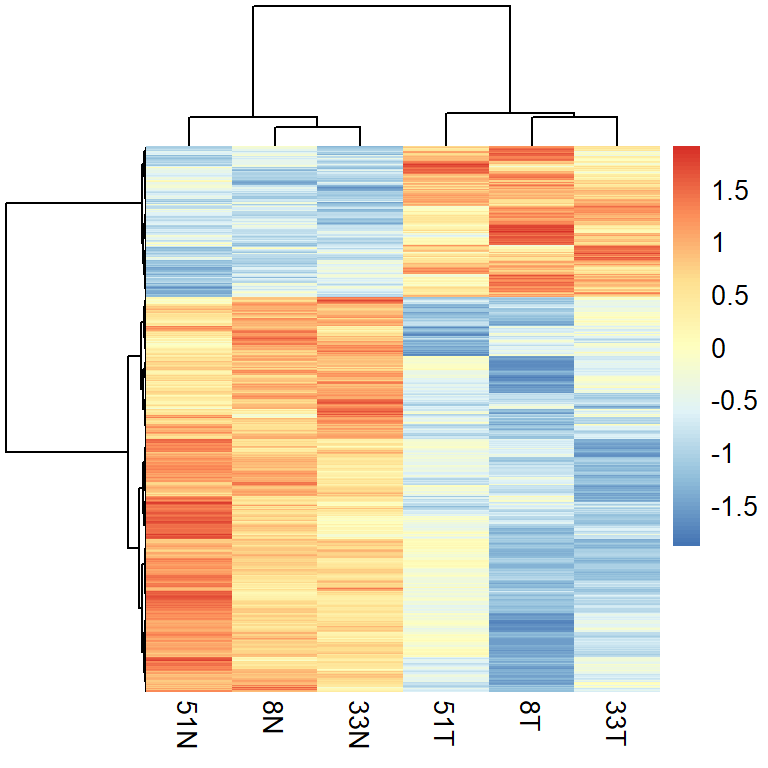

```r
# 遺伝子ごとにスケーリング
pheatmap(mat_DEG,
         scale = "row",
         show_rownames = F,
         clustering_method = "ward.D")
```

### 個々の遺伝子発現

数個の遺伝子をplotするのであれば、boxplotやviolinplotを使うのも有用です。

最も有意に発現上昇していたPTHLHの発現を可視化してみます。

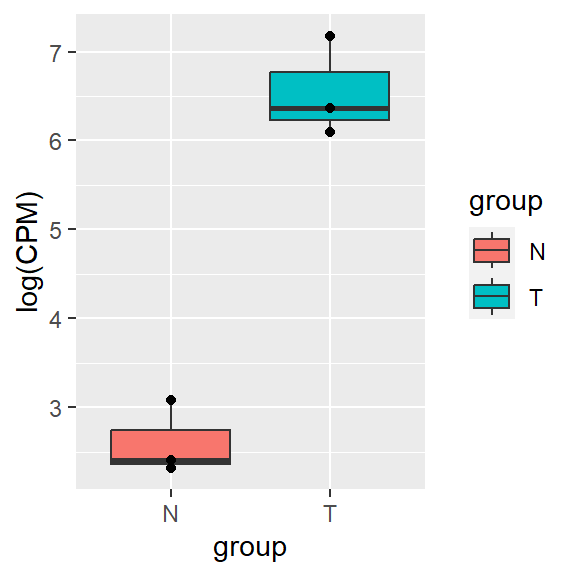

```r
# PTHLHの発現値を取り出す
target <- mat["PTHLH",,drop=F]

# ロング型に変換
target <- reshape2::melt(target)

# 群の情報が無いので追記
target$group <- c("N", "T", "N", "T", "N", "T")

ggplot(data = target, mapping = aes(x = group, y = value)) +
  geom_boxplot(aes(fill = group)) +
  geom_point() +
  labs(y = "log(CPM)")
```

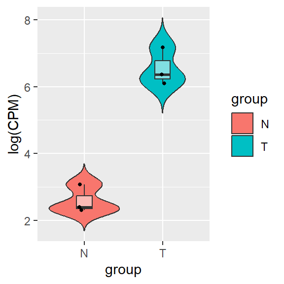

```r
ggplot(data = target, mapping = aes(x = group, y = value)) +
  geom_violin(aes(fill = group), trim = F) +
  geom_boxplot(width = 0.2, fill = "white", alpha = 0.5) +
  geom_jitter(height = 0, width = 0.1, size = 1) +
  labs(y = "log(CPM)")
```